# Mandeng

# What people whatching on Netflix during this period"

# I-Background

## I-1. Background explanation

We are in a crisis situation that has led us to change our habits. Today, more than half of the world’s population remains confined. Some of them have lost their jobs, their activities which cannot be replaced by telework.Peoples are changing their behaviours.They involuntarily find themselves in front of the TV or on their computers watching TV shows or movies.

We asked ourselves how **Netflix** is handling this abundant flow of customers on their platforms, what activities (series, movies, innovations) are popular, and how netflix customers feel about the streaming service during this period.

## I-2. Description of the search query

To analyse what’s being said on netflix, we analysed all tweets that mention netflix and decided to take 72,000 tweets between “2020-04-30 14:07:55” and “2020-05-01 14:51:05”.

## I-3. Some general data

```r
netflix=read.csv(file='C:/Users/jm_ma/Desktop/cours text analysis/multiTimeline.csv')
```

Number of searches on **Netflix** over 12 months in the world.

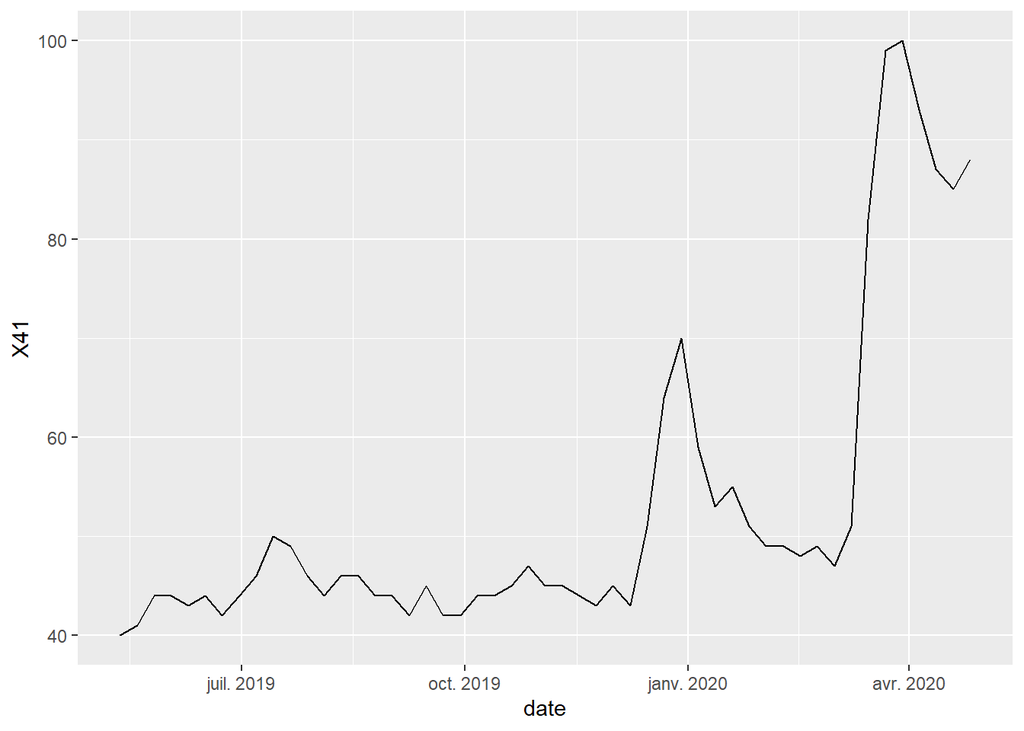

```r
setDT(netflix)
netflix$date <- as.Date(netflix$X2019.05.05)
ggplot(netflix, aes(x=date, y=X41)) + geom_line()
```

We’re uploading the file of tweets we recorded

```r
load(file ='tweets.RData' )
```

## Our data:

```r
tweets.df=A.df
```

changing dataframe to data.table

```r
setDT(tweets.df)
```

## Number of tweets per country

```r
tweets.df[,.(.N), by = .(country)] [order(-N)]
```

```
##                         country     N
##  1:                        <NA> 69705
##  2:               United States  1249
##  3:              United Kingdom   256
##  4: Republic of the Philippines   104
##  5:                      Canada    84
##  6:                       India    80
##  7:                     Nigeria    54
##  8:                South Africa    47
##  9:                      Brazil    40
## 10:                   Australia    30
## 11:                    Malaysia    24
## 12:                     Ireland    23
## 13:                   Indonesia    19
## 14:                      France    13
```

[output cut: 79 more lines]

As you can see, the people who talk more about netflix are more in the USA.

```r
tweets.df[, chunk:= created_at %>% cut(breaks = "5 min") %>% as.factor ]
```

## Retweet_count, quotes and like by country

```r
tweets.df[,.(TotalTweets = .N,
             total_reactions=sum(retweet_count, na.rm = TRUE) +
                sum(favorite_count, na.rm = TRUE)+
                sum(reply_count, na.rm = TRUE)+
                sum(quote_count, na.rm = TRUE)),
          by = .(country)] [order(-total_reactions)]
```

```
##                         country TotalTweets total_reactions
##  1:                        <NA>       69705          472702
##  2:               United States        1249            4394
##  3:              United Kingdom         256            1080
##  4:                       India          80             276
##  5:                      Canada          84             202
##  6:                South Africa          47             166
##  7:                     Germany          12             115
##  8: Republic of the Philippines         104             111
##  9:                     Nigeria          54              70
## 10:                   Singapore           9              63
## 11:                       Italy           6              61
## 12:                Sierra Leone           1              55
## 13:                     Ireland          23              46
## 14:                      Brazil          40              36
```

[output cut: 79 more lines]